# UFRGS - Especialização em Ciência de Dados SERPRO - INF/UFRGS (2022-2023)

| **Disciplina** | :CD001-Estatística |
| --- | --- |
| **Professora** | :Lisiane Selau |
| **Aluno** | :Strauss Cunha Carvalho |
| **Labarotório** | :LAB-00 |
| **Data** | :11/03/2022 |

##### **Github do Laboratório 00 - Markdown**

- [Github] (https://github.com/stra-uss/ufrgs-posgrad/blob/main/cd001-statistics/ufrgs-estatistica-strauss-lab00.md)

##### **Laboratório 0 - LAB-00**

##### Nas páginas anteriores, você recriou algumas das exposições e análises preliminares dos dados de batismo de Arbuthnot. Sua tarefa consiste repetir essas etapas, mas para os registros atuais de nascimento dos Estados Unidos.

- Carregue os dados atuais com o seguinte comando.

```bash
[openinto] ("<http://www.openintro.org/stat/data/present.R>")
```

- Carregamento dos Datasets

```r
source("http://www.openintro.org/stat/data/present.R")
source("http://www.openintro.org/stat/data/arbuthnot.R")
```

- Pré-visualização dos tipos de variáveis dataset

```r
str(present)
```

```
## 'data.frame':    63 obs. of  3 variables:
##  $ year : num  1940 1941 1942 1943 1944 ...
##  $ boys : num  1211684 1289734 1444365 1508959 1435301 ...
##  $ girls: num  1148715 1223693 1364631 1427901 1359499 ...
```

- Pré-visualização de uma pequena amostra do dataset

```r
head(present, 5)
```

```
##   year    boys   girls
## 1 1940 1211684 1148715
## 2 1941 1289734 1223693
## 3 1942 1444365 1364631
## 4 1943 1508959 1427901
## 5 1944 1435301 1359499
```

- Carregamento (ou instalação de R Packages necessários)

```r
#install.packages("ggplot2")
#install.packages("dplyr")
#install.packages("gridExtra")
library(ggplot2)
library(dplyr, warn.conflicts = FALSE)
library("gridExtra", warn.conflicts = FALSE)
```

##### **Tarefas:**

##### **1. Quais anos estão incluídos neste conjunto de dados? Quais são as dimensões da base de dados e quais são os nomes das colunas ou variáveis?**

- Total de anos no dataset:

```r
n_distinct(present$year)
```

```
## [1] 63
```

- Dimensões do dataset (linhas e colunas):

```r
dim(present)
```

```
## [1] 63  3
```

- Variáveis independentes do dataset:

```r
names(present)
```

```
## [1] "year"  "boys"  "girls"
```

##### **2. Como estas contagens se comparam aos dados de Arbuthnot? Eles estão numa escala similar?**

- Conforme gráficos a seguir, observa-se, no estudo de Arbuthnot, a partir do ano de 1660, um aumento na quantidade de batismos e, consequentemente, nascimentos.
- Posteriormente, no período de 1940 a 2000, baseando-se no dataset de nascimento nos Estados Unidos, visualmente, observa-se, no período de 1940 a 1960, a mesma tendência de aumento, porém numa escala maior.
- Entretanto, observa-se, no início da década de 1960 um significativo decaimento da curva de nascimento.
- Curiosamente, a título de informação, conforme [1] (https://www.dw.com/pt-br/1960-primeira-p%C3%ADlula-anticoncepcional-chega-ao-mercado/a-611248#), o anticoncepcional fora colocado em uso à população estadunidense em 1960, ou seja, um ano antes do pico de nascimentos naquele país do norte. Viva a ciência!
- A partir da primeira metade da década de 1970 voltou a ter um aumento nos nascimentos, atingindo, em 1990, um valor de máximo local. Posteriormente, voltou a decair e oscilar até o ano 2000.

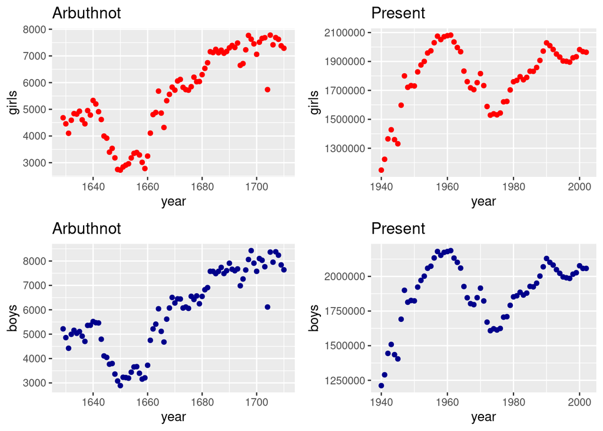

```r
plt_girls_arbuthnot = ggplot(arbuthnot) + geom_point(mapping = aes(x = year, y = girls) , color="red") + ggtitle("Arbuthnot")
plt_guys_arbuthnot = ggplot(arbuthnot) + geom_point(mapping = aes(x = year, y = boys), color='darkblue') + ggtitle("Arbuthnot")
plt_girls_present = ggplot(present) + geom_point(mapping = aes(x = year, y = girls), color="red") + ggtitle("Present")
plt_guys_present = ggplot(present) + geom_point(mapping = aes(x = year, y = boys), color="darkblue") + ggtitle("Present")
grid.arrange(plt_girls_arbuthnot, plt_girls_present, plt_guys_arbuthnot, plt_guys_present, nrow=2, ncol=2)
```

##### **3. A observação de Arbuthnot de que os meninos nascem numa proporção maior que as meninas se mantém nos EUA?**

- Sim, conforme observado visualmente, ou seja, sem rigor estatístico, nos gráficos a seguir, a taxa de nascimento de meninos é superior à taxa de meninas.

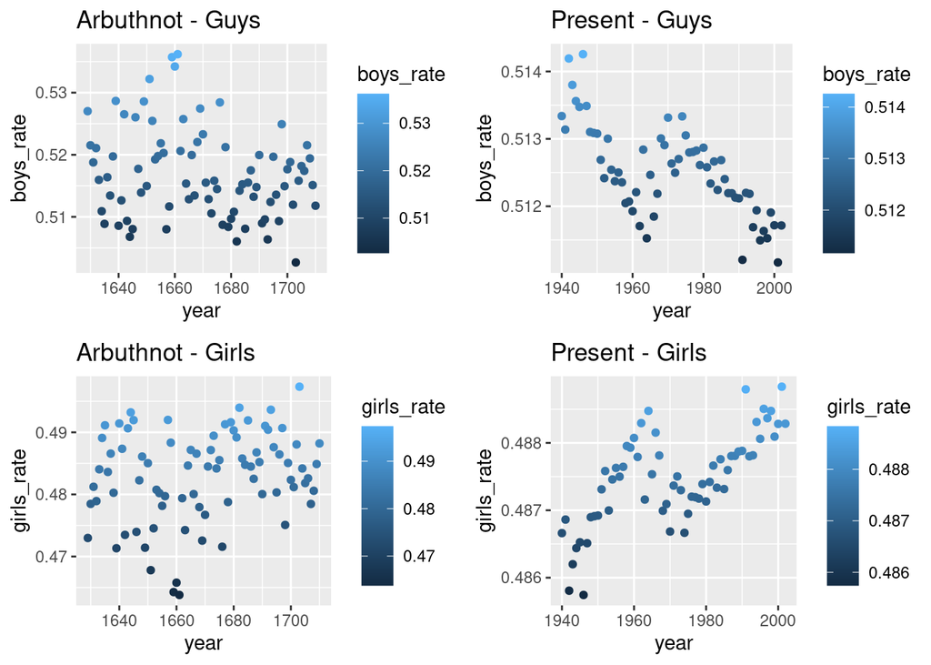

```r
boys_rate_arbuthnot = arbuthnot %>%
  mutate(boys_rate = arbuthnot$boys / (arbuthnot$boys + arbuthnot$girls)) %>%
  ggplot() +
  geom_point(aes(x = year, y = boys_rate, color = boys_rate)) + ggtitle("Arbuthnot - Guys")

girls_rate_arbuthnot = arbuthnot %>%
  mutate(girls_rate = arbuthnot$girls / (arbuthnot$boys + arbuthnot$girls)) %>%
  ggplot() +
  geom_point(aes(x = year, y = girls_rate, color = girls_rate)) + ggtitle("Arbuthnot - Girls")

boys_rate_present = present %>%
  mutate(boys_rate = present$boys / (present$boys + present$girls)) %>%
  ggplot() +
  geom_point(aes(x = year, y = boys_rate, color = boys_rate)) + ggtitle("Present - Guys")

girls_rate_present = present %>%
  mutate(girls_rate = present$girls / (present$boys + present$girls)) %>%
  ggplot() +
  geom_point(aes(x = year, y = girls_rate, color = girls_rate)) + ggtitle("Present - Girls")

grid.arrange(boys_rate_arbuthnot, boys_rate_present, girls_rate_arbuthnot, girls_rate_present,  nrow=2, ncol=2)
```

- Complementando, a título de curiosidade, nos dois gráficos a seguir referentes aos dois estudos, observam-se, que as linhas na cor azul (meninos) superam a linha da cor vermelha (meninas), em toda linha do tempo.

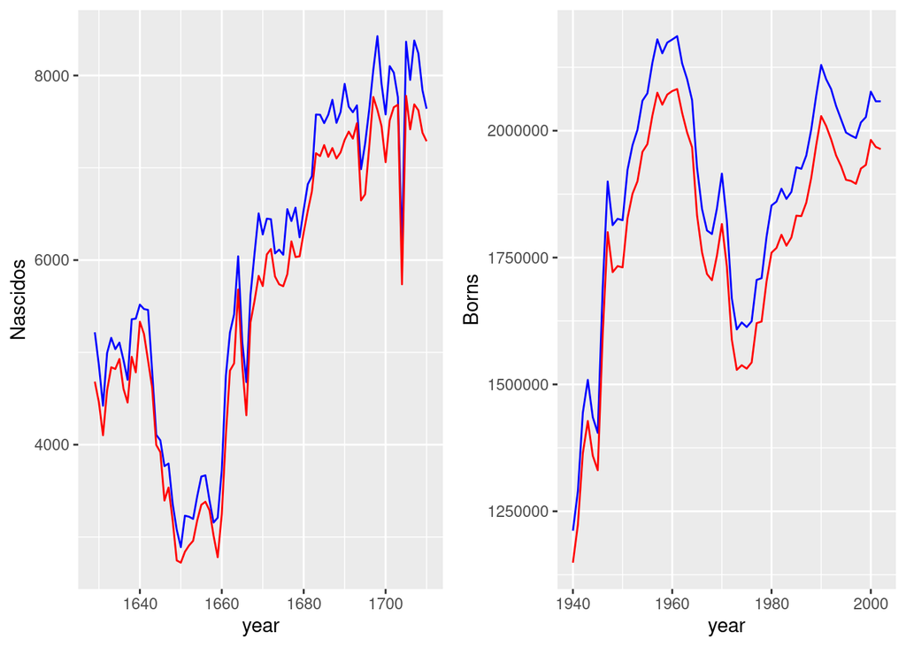

```r
borns_arbuthnot = ggplot(arbuthnot, aes(year)) +
  geom_line(aes(y = boys, colour = "boys"),  color="blue") +
  geom_line(aes(y = girls, colour = "girls"), color="red") + ylab("Nascidos")

borns_present = ggplot(present, aes(year)) +
  geom_line(aes(y = boys, colour = "boys"), color="blue") +
  geom_line(aes(y = girls, colour = "girls"), color= "red") + ylab("Borns")

grid.arrange(borns_arbuthnot, borns_present,  nrow=1, ncol=2)
```

##### **4. Crie um gráfico que mostre a razão de meninos para meninas para cada ano do conjunto de dados. O que você pode verificar?**

- Como se pode observar nos gráficos a seguir, a razão de meninos por meninas é superior a 1 na maior parte do dataset. O contrário, ou seja, as meninas no numerador, tem-se a razão sempre inferior a 1.
- Portanto, fornecendo indícios de que se nasce, nos dois períodos de tempo observados, mais meninos do que meninas.

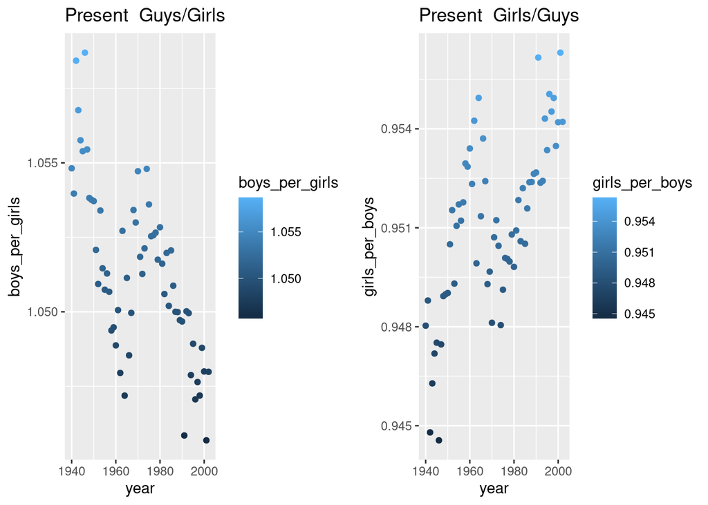

```r
boys_per_girls = present %>%
  mutate(boys_per_girls = present$boys/present$girls) %>%
  ggplot() +
  geom_point(aes(x = year, y = boys_per_girls, color = boys_per_girls)) + ggtitle("Present  Guys/Girls")

girls_per_boys = present %>%
  mutate(girls_per_boys = present$girls/present$boys) %>%
  ggplot() +
  geom_point(aes(x = year, y = girls_per_boys, color = girls_per_boys)) + ggtitle("Present  Girls/Guys")

grid.arrange(boys_per_girls, girls_per_boys, nrow=1, ncol=2)
```

##### **5. Em qual ano se verifica o maior número de nascimentos nos EUA?**

###### Você pode utilizar os arquivos de ajuda ou o cartão de referência do R (http://cran.r-project.org/doc/contrib/Short-refcard.pdf ) para encontrar comandos úteis.

- Como se observa no gráfico a seguir, no ano de 1961, o ponto de máximo absoluto do dataset, foi quando houve o maior número de nascimentos nos EUA.
- Logo nos anos seguintes, observa-se um decaimento, como provável explicação, citada em [1].

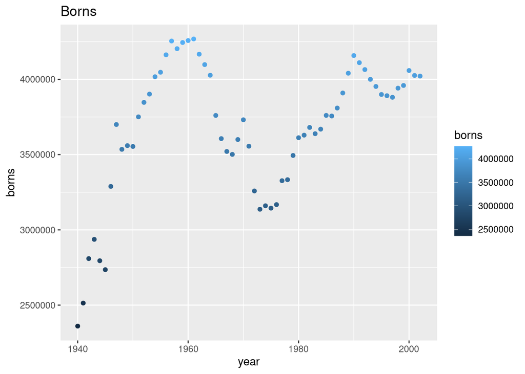

```r
present %>%
  mutate(borns = present$boys+present$girls) %>%
  ggplot() +
  geom_point(aes(x = year, y = borns, color = borns)) + ggtitle("Borns")
```

- Pico de nascimentos por ano:

```r
present %>%
    filter(boys+girls == max(boys+girls)) %>% # filter the data.frame to keep row where x is maximum
    select(year) # select column y)
```

```
##   year
## 1 1961
```

- Total de nascimentos no ano de 1961:

```r
max(present$boys+present$girls)
```

```
## [1] 4268326
```

##### **Referencias**

- [1] (https://www.dw.com/pt-br/1960-primeira-p%C3%ADlula-anticoncepcional-chega-ao-mercado/a-611248#)